# Project_CombinedAnalysis

Rebecca Waag

18 6 2023

# Combining stress-induced changes in accessibility and transcription factor binding

Here, we have a closer look at the stress-responsive peaks from the ATAC and ChIP dataset.

```r
suppressPackageStartupMessages({
  library(epiwraps)
  library(motifmatchr)
  library(MotifDb)
  library(universalmotif)
  library(Biostrings)
  library(TFBSTools)
  library(PWMEnrich)
  library(sechm)
  library(BiocParallel)
  library(memes) #for meme-based methods
  library(ggplot2)
  library(chromVAR) # for motif accessibility estimation
  library(rtracklayer)
  library(AnnotationHub)
  library(rGREAT)
  library(GenomicRanges)
})
```

[output not shown]

```
## See system.file("LICENSE", package="MotifDb") for use restrictions.
```

```r
# to control multithreading, unix users can use:
register(MulticoreParam(4))
ah <- AnnotationHub()
```

```
## snapshotDate(): 2020-10-27
```

## Find overlap between stress ATAC peaks and ChIP peaks

```r
#ATAC peaks from NF that are stress responsive and downregulated
ATAC_sigdown <- readRDS("/mnt/bohacek/rebecca/training/EpiC/Project/peaksM_NF_stress_sigdown.rds")
ATAC_sigdown #43 ranges
```

```
## GRanges object with 43 ranges and 1 metadata column:
##        seqnames              ranges strand |                     revmap
##           <Rle>           <IRanges>  <Rle> |              <IntegerList>
##    [1]        1   23821684-23821971      * |       866456,455236,691411
##    [2]        1 105944999-105945454      * |    3424,1721096,185244,...
##    [3]        1 158310441-158310800      * | 871689,1527934,1310164,...
##    [4]        1 173335990-173336182      * |   187736,637913,694803,...
##    [5]       10   12938876-12938978      * |       136798,638678,189111
##    ...      ...                 ...    ... .                        ...
##   [39]        8   67631709-67632064      * |  559489,1802177,854286,...
##   [40]        8   87228789-87229201      * |   751381,969184,628565,...
##   [41]        9   30784357-30784467      * |       564335,972864,753514
##   [42]        9 108073034-108073490      * |  452506,374626,1714309,...
##   [43]        9 110617196-110617403      * |   374825,977697,863155,...
##   -------
##   seqinfo: 49 sequences from an unspecified genome; no seqlengths
```

```r
seqlevelsStyle(ATAC_sigdown) <- "NCBI"

#ATAC peaks from NF that are stress responsive and upregulated
ATAC_sigup <- readRDS("/mnt/bohacek/rebecca/training/EpiC/Project/peaksM_NF_stress_sigup.rds")
ATAC_sigup #868 ranges
```

```
## GRanges object with 868 ranges and 1 metadata column:
##         seqnames              ranges strand |                      revmap
##            <Rle>           <IRanges>  <Rle> |               <IntegerList>
##     [1]        1     9851400-9851770      * | 1037690,1902886,1523898,...
##     [2]        1     9859461-9859655      * | 1304883,1037693,1523899,...
##     [3]        1   14192796-14193121      * | 1812774,1988875,1305004,...
##     [4]        1   14244792-14245206      * | 1037764,1988879,1305008,...
##     [5]        1   15913533-15913931      * |     1524016,1305039,1718321
##     ...      ...                 ...    ... .                         ...
##   [864]        X 140505795-140506243      * |  757813,1717494,1988234,...
##   [865]        X 140513436-140513681      * | 1988236,1412780,1304113,...
##   [866]        X 142794076-142794519      * |  1412831,571782,1606272,...
##   [867]        X 159459025-159459330      * | 1523521,1717816,1037442,...
##   [868]        X 167164770-167165062      * | 1988563,1188751,1812530,...
##   -------
##   seqinfo: 49 sequences from an unspecified genome; no seqlengths
```

```r
seqlevelsStyle(ATAC_sigup) <- "NCBI"

#GR peaks from that are stress responsive and upregulated
GR_sigup <- readRDS("/mnt/bohacek/rebecca/training/EpiC/Project/peaksR_GR_stress_sigup_sh.rds")
GR_sigup #1695 ranges
```

```
## GRanges object with 1695 ranges and 1 metadata column:
##                         seqnames              ranges strand |      bias
##                            <Rle>           <IRanges>  <Rle> | <numeric>
##      10:7705652-7706038    chr10     7705652-7706038      * |  0.434109
##      10:9014695-9015098    chr10     9014695-9015098      * |  0.451220
##      10:9342551-9342877    chr10     9342551-9342877      * |  0.440541
##    10:12779306-12779720    chr10   12779306-12779720      * |  0.393365
##    10:14180092-14180431    chr10   14180092-14180431      * |  0.463636
##                     ...      ...                 ...    ... .       ...
##   X:140511231-140511685     chrX 140511231-140511685      * |  0.521940
##   X:140520159-140520502     chrX 140520159-140520502      * |  0.575581
##   X:140567757-140568051     chrX 140567757-140568051      * |  0.464646
##     X:36390022-36390420     chrX   36390022-36390420      * |  0.466993
##     X:36823906-36824298     chrX   36823906-36824298      * |  0.500000
##   -------
##   seqinfo: 24 sequences from an unspecified genome; no seqlengths
```

```r
seqlevelsStyle(GR_sigup) <- "NCBI"

#GR peaks from that are stress responsive and downregulated
GR_sigdown <- readRDS("/mnt/bohacek/rebecca/training/EpiC/Project/peaksR_GR_stress_sigdown_sh.rds")
GR_sigdown #342 ranges
```

```
## GRanges object with 0 ranges and 1 metadata column:
##    seqnames    ranges strand |      bias
##       <Rle> <IRanges>  <Rle> | <numeric>
##   -------
##   seqinfo: 24 sequences from an unspecified genome; no seqlengths
```

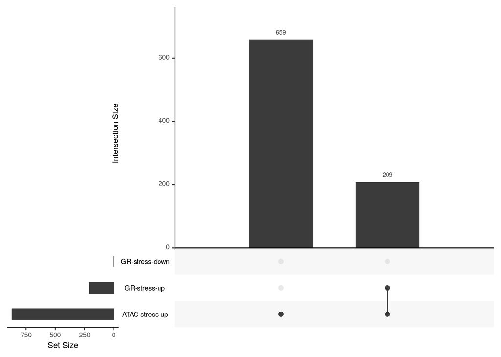

FIGURE 1: Upsetplot showing how many of the sign. ATAC peaks overlap with the sign. GR ChIP peaks

```r
seqlevelsStyle(GR_sigdown) <- "NCBI"

#combine peaks into one object
ATAC_GR<- list("GR-stress-up" = GR_sigup, "GR-stress-down" = GR_sigdown, "ATAC-stress-up" = ATAC_sigup, "ATAC-stress-down" = ATAC_sigdown)

#plot overlap of regions
#regionUpset(ATAC_GR)
regionUpset(ATAC_GR, reference = ATAC_GR$`ATAC-stress-up`)
```

```r
#Calculate the proportion of upregulated ATAC peaks that can be explained by GR binding
ATACandGR <- ATAC_sigup[overlapsAny(ATAC_sigup, GR_sigup)]
prop <- length(ATACandGR)/length(ATAC_sigup)
prop #0.2407834
```

```
## [1] 0.2407834
```

209 of the 868 sign. more accessible ATAC peaks overlap with significantly more peaks bound by GR as detected by GR ChIP (Fig. 1). This accounts for 24% of the sign. more accessible ATAC peaks.

As GR and MR binding occurs at overlapping loci, we next included MR in the analysis.

```r
#MR peaks from that are stress responsive and upregulated
MR_sigup <- readRDS("/mnt/bohacek/rebecca/training/EpiC/Project/peaksR_MR_stress_sigup_sh.rds")
MR_sigup #1157 ranges
```

```
## GRanges object with 1157 ranges and 1 metadata column:
##                         seqnames              ranges strand |      bias
##                            <Rle>           <IRanges>  <Rle> | <numeric>
##      10:9014695-9015098    chr10     9014695-9015098      * |  0.451220
##      10:9342551-9342877    chr10     9342551-9342877      * |  0.440541
##    10:14180092-14180431    chr10   14180092-14180431      * |  0.463636
##    10:19522200-19522868    chr10   19522200-19522868      * |  0.466454
##    10:20130919-20131500    chr10   20130919-20131500      * |  0.480392
##                     ...      ...                 ...    ... .       ...
##   X:140520159-140520502     chrX 140520159-140520502      * |  0.575581
##     X:36390022-36390420     chrX   36390022-36390420      * |  0.466993
##     X:37838531-37838697     chrX   37838531-37838697      * |  0.593443
##     X:37890154-37890220     chrX   37890154-37890220      * |  0.593443
##     X:37681995-37682107     chrX   37681995-37682107      * |  0.593443
##   -------
##   seqinfo: 24 sequences from an unspecified genome; no seqlengths
```

```r
seqlevelsStyle(MR_sigup) <- "NCBI"

#MR peaks from that are stress responsive and upregulated
MR_sigdown <- readRDS("/mnt/bohacek/rebecca/training/EpiC/Project/peaksR_MR_stress_sigdown_sh.rds")
MR_sigdown #107 ranges
```

```
## GRanges object with 107 ranges and 1 metadata column:
##                         seqnames              ranges strand |      bias
##                            <Rle>           <IRanges>  <Rle> | <numeric>
##    17:14035908-14036394    chr17   14035908-14036394      * |  0.484848
##    17:14005036-14005578    chr17   14005036-14005578      * |  0.525810
##    17:22043906-22044023    chr17   22043906-22044023      * |  0.525810
##    17:14003044-14003783    chr17   14003044-14003783      * |  0.480103
##    17:13881263-13881322    chr17   13881263-13881322      * |  0.489691
##                     ...      ...                 ...    ... .       ...
##   X:155092147-155092335     chrX 155092147-155092335      * |  0.481293
##   X:154958761-154959161     chrX 154958761-154959161      * |  0.481293
##   X:131914658-131914845     chrX 131914658-131914845      * |  0.407787
##   X:135681809-135682185     chrX 135681809-135682185      * |  0.615183
##   X:145885420-145885547     chrX 145885420-145885547      * |  0.343284
##   -------
##   seqinfo: 24 sequences from an unspecified genome; no seqlengths
```

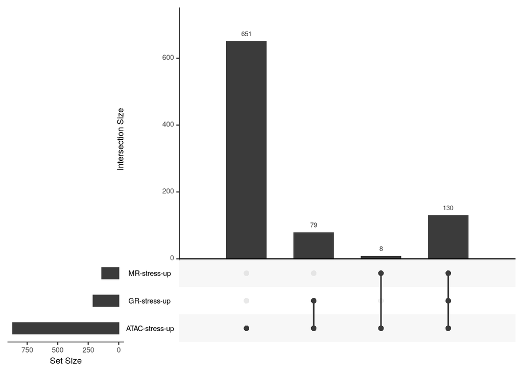

FIGURE 2: Upsetplot showing how many of the sign. ATAC peaks overlap with the sign. more bound GR and MR ChIP peaks

```r
seqlevelsStyle(MR_sigdown) <- "NCBI"

#we focus on regions with increased accessibility upon stress
ATAC_GR_MR_up<- list("GR-stress-up" = GR_sigup, "ATAC-stress-up" = ATAC_sigup, "MR-stress-up" = MR_sigup)

#plot overlap
regionUpset(ATAC_GR_MR_up, reference = ATAC_GR_MR_up$`ATAC-stress-up`)
```

Visualizing the overlaps in an Upset plot reveals that 130 of the ATAC peaks overlap with both GR and MR. While 79 peaks exclusively overlap with GR, only 8 exclusively overlap with MR (Fig. 2). 651 ATAC peaks show no overlap with either GR or MR.

# Visualize signal using tracks

```r
tracks <- list.files("/mnt/bohacek/rebecca/training/EpiC/Project/data_Marrocco/NFtracks/", pattern="bw$", full=TRUE)
names(tracks) <- gsub("\\.bw","",basename(tracks))
#names(tracks)<- c(rep("no acute", 12), rep("acute", 12))
tracks <- tracks[1:24]
length(tracks) # 24 files
```

```
## [1] 24
```

## Accessibility peaks that do also bind GR

Only the control and FSS group will be used to plot the coverage.

```r
#subset peaks that that show both increased accessibility and increased GR binding upon stress
ATACandGR <- ATAC_sigup[overlapsAny(ATAC_sigup, GR_sigup)] #209 ranges
#read signal around overlapping peaks
sm2 <- signal2Matrix(tracks, ATACandGR, w=5, extend=2000)
```

```
## Reading /mnt/bohacek/rebecca/training/EpiC/Project/data_Marrocco/NFtracks//ARS_female_GSM6041847.shifted.bw
```

```
## Reading /mnt/bohacek/rebecca/training/EpiC/Project/data_Marrocco/NFtracks//ARS_female_GSM6041848.shifted.bw
```

```
## Reading /mnt/bohacek/rebecca/training/EpiC/Project/data_Marrocco/NFtracks//ARS_female_GSM6041849.shifted.bw
```

```
## Reading /mnt/bohacek/rebecca/training/EpiC/Project/data_Marrocco/NFtracks//ARS_male_GSM6041850.shifted.bw
```

```
## Reading /mnt/bohacek/rebecca/training/EpiC/Project/data_Marrocco/NFtracks//ARS_male_GSM6041851.shifted.bw
```

```
## Reading /mnt/bohacek/rebecca/training/EpiC/Project/data_Marrocco/NFtracks//ARS_male_GSM6041852.shifted.bw
```

```
## Reading /mnt/bohacek/rebecca/training/EpiC/Project/data_Marrocco/NFtracks//Control_female_GSM6041841.shifted.bw
```

```
## Reading /mnt/bohacek/rebecca/training/EpiC/Project/data_Marrocco/NFtracks//Control_female_GSM6041842.shifted.bw
```

```
## Reading /mnt/bohacek/rebecca/training/EpiC/Project/data_Marrocco/NFtracks//Control_female_GSM6041843.shifted.bw
```

```
## Reading /mnt/bohacek/rebecca/training/EpiC/Project/data_Marrocco/NFtracks//Control_male_GSM6041844.shifted.bw
```

```
## Reading /mnt/bohacek/rebecca/training/EpiC/Project/data_Marrocco/NFtracks//Control_male_GSM6041845.shifted.bw
```

```
## Reading /mnt/bohacek/rebecca/training/EpiC/Project/data_Marrocco/NFtracks//Control_male_GSM6041846.shifted.bw
```

```
## Reading /mnt/bohacek/rebecca/training/EpiC/Project/data_Marrocco/NFtracks//Double-hit_female_GSM6041859.shifted.bw
```

```
## Reading /mnt/bohacek/rebecca/training/EpiC/Project/data_Marrocco/NFtracks//Double-hit_female_GSM6041860.shifted.bw
```

```
## Reading /mnt/bohacek/rebecca/training/EpiC/Project/data_Marrocco/NFtracks//Double-hit_female_GSM6041861.shifted.bw
```

```
## Reading /mnt/bohacek/rebecca/training/EpiC/Project/data_Marrocco/NFtracks//Double-hit_male_GSM6041862.shifted.bw
```

```
## Reading /mnt/bohacek/rebecca/training/EpiC/Project/data_Marrocco/NFtracks//Double-hit_male_GSM6041863.shifted.bw
```

```
## Reading /mnt/bohacek/rebecca/training/EpiC/Project/data_Marrocco/NFtracks//Double-hit_male_GSM6041864.shifted.bw
```

```
## Reading /mnt/bohacek/rebecca/training/EpiC/Project/data_Marrocco/NFtracks//FSS_female_GSM6041853.shifted.bw
```

```
## Reading /mnt/bohacek/rebecca/training/EpiC/Project/data_Marrocco/NFtracks//FSS_female_GSM6041854.shifted.bw
```

```
## Reading /mnt/bohacek/rebecca/training/EpiC/Project/data_Marrocco/NFtracks//FSS_female_GSM6041855.shifted.bw
```

```
## Reading /mnt/bohacek/rebecca/training/EpiC/Project/data_Marrocco/NFtracks//FSS_male_GSM6041856.shifted.bw
```

```
## Reading /mnt/bohacek/rebecca/training/EpiC/Project/data_Marrocco/NFtracks//FSS_male_GSM6041857.shifted.bw
```

```
## Reading /mnt/bohacek/rebecca/training/EpiC/Project/data_Marrocco/NFtracks//FSS_male_GSM6041858.shifted.bw
```

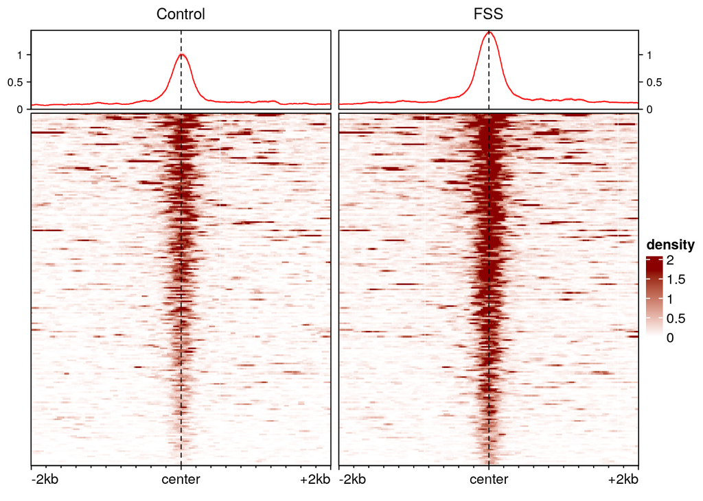

FIGURE 3: Enriched Hatmap showing the read coverage around the sign. more accessible peaks upon stress bound by GR

```r
#combine all control and all FSS samples
smm2 <- list(Control=mergeSignalMatrices(sm2[grep("Control",names(sm2))]),
            FSS=mergeSignalMatrices(sm2[grep("FSS",names(sm2))]))

#plot signal
plotEnrichedHeatmaps(smm2, trim=0.95, colors = c("white","darkred"))
```

A clear difference is visible between the coverage, showing a higher signal in the FSS group (Fig. 3).

We perform clustering to test, whether different coverage tracks show different patterns.

```r
#look whether there are any clusters emerging between those peaks
#check for number of clusters that define a certain variability
#cl <- clusterSignalMatrices(smm2, k=2:10)
#ggplot(cl$varExplained, aes(k, varExplained)) + geom_line()
```

3 clusters are used to cluster the signal based on the explained variance per added clsuter.

```r
#cluster signal
#set seed to ensure reproducibility of clustering
set.seed(123)
#clustering signal with kmeans into 3 clusters, the relative signal instead of absolute values is used
cl <- epiwraps::clusterSignalMatrices(smm2, k=3, scaleRows = TRUE, seed=TRUE) #3 clusters explain 76% of variance
```

```
##   ~76% of the variance explained by clusters
```

```r
#use scaleRows=RUE?

#add cluster information to the GRanges object
ATACandGR$clusters <- cl
#regions
#compare number of regions in each cluster
table(cl)
```

```
## cl
##   1   2   3
##  33  33 143
```

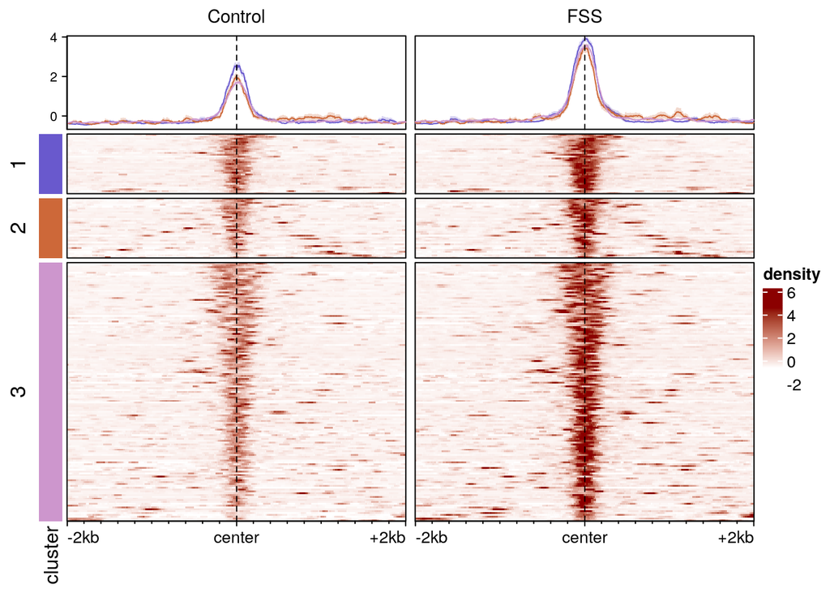

FIGURE 4: Enriched Hatmap showing the read coverage around the sign. more accessible peaks upon stress bound by GR for the individual clusters

```r
#define colors for clusters
mycolors <-c("1"="slateblue3", "2"="sienna3", "3"="plum3", "4"="red", "5"="blue")
#plot heatmap with clusters
plotEnrichedHeatmaps(smm2, row_split=cl, mean_color = mycolors, colors=c("white", "darkred"), scale_row="global")
```

By plotting the tracks split into clusters, no clear differences between the signals emerge (Fig. 4), therefore, the clusters are plotted individually for the two groups.

```r
#overlay for one cluster all of the marks
d<-meltSignals(smm2, splitBy=cl)
head(d)
```

```
##   split position  sample       mean         SD         SE     median
## 1     1    -2000 Control 0.06068333 0.07876441 0.01371112 0.04105980
## 2     1    -1995 Control 0.05724622 0.06868315 0.01195620 0.03753659
## 3     1    -1990 Control 0.05638470 0.07446753 0.01296313 0.03480221
## 4     1    -1985 Control 0.05642262 0.07452925 0.01297388 0.02217270
## 5     1    -1980 Control 0.05108999 0.07071600 0.01231008 0.02217270
## 6     1    -1975 Control 0.04984005 0.06195340 0.01078470 0.02911319
```

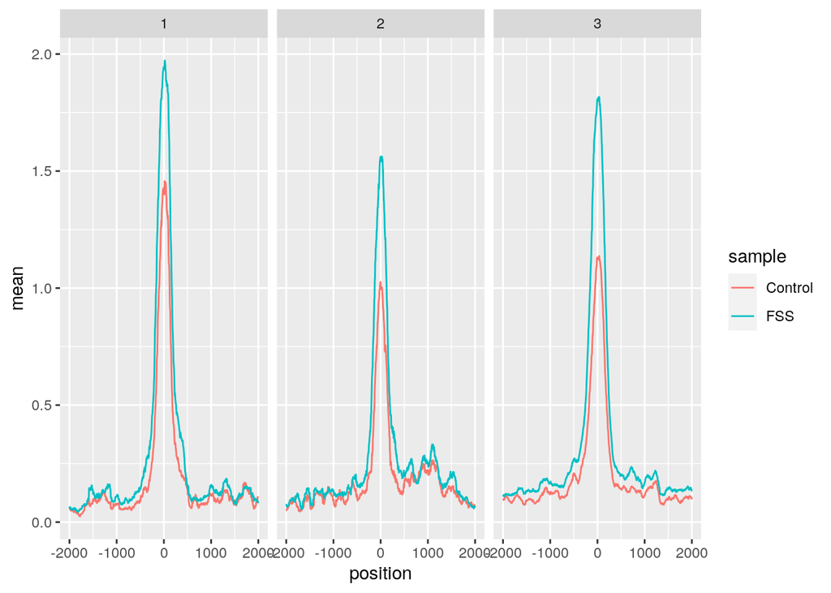

FIGURE 5: Read coverage between control and FSS samples for each cluster

```r
ggplot(d, aes(position, mean, colour=sample))+geom_line() +facet_wrap(~split)
```

Looking at the individual clusters, the pattern seems very similar in all of them, with certain differences in the overall baseline coverage (Fig. 5). The center position shows an enhanced signal for all clusters in the FSS group.

# Accessibility peaks that do not also bind GR or MR

we also plot the signal for those accessibility peaks that cannot be explained by GR or MR.

```r
#extract those peaks that cannot be explained by GR and MR action
ATAC_noex <- ATAC_sigup[!overlapsAny(ATAC_sigup, GR_sigup)]
ATAC_noex <- ATAC_noex[!overlapsAny(ATAC_noex, MR_sigup)]
ATAC_noex #651 ranges
```

```
## GRanges object with 651 ranges and 1 metadata column:
##         seqnames              ranges strand |                      revmap
##            <Rle>           <IRanges>  <Rle> |               <IntegerList>
##     [1]        1     9851400-9851770      * | 1037690,1902886,1523898,...
##     [2]        1     9859461-9859655      * | 1304883,1037693,1523899,...
##     [3]        1   14192796-14193121      * | 1812774,1988875,1305004,...
##     [4]        1   15913533-15913931      * |     1524016,1305039,1718321
##     [5]        1   25008511-25009238      * | 1305263,1718504,1903158,...
##     ...      ...                 ...    ... .                         ...
##   [647]        X   85122408-85122580      * | 1605804,1811668,1412239,...
##   [648]        X 140513436-140513681      * | 1988236,1412780,1304113,...
##   [649]        X 142794076-142794519      * |  1412831,571782,1606272,...
##   [650]        X 159459025-159459330      * | 1523521,1717816,1037442,...
##   [651]        X 167164770-167165062      * | 1988563,1188751,1812530,...
##   -------
##   seqinfo: 49 sequences from an unspecified genome; no seqlengths
```

## Perform enrichment analysis

```r
#perform enrichment analysis using rGREAT server
library(rGREAT)

#adjust seqlevelStyle for rGREAT server
seqlevelsStyle(ATAC_noex) <- "UCSC"
ATAC_peaks <- readRDS("/mnt/bohacek/rebecca/training/EpiC/Project/merged_peaksM_NF.rds")
seqlevelsStyle(ATAC_peaks) <- "UCSC"

chrom <- c("chr1", "chr10", "chr11", "chr12", "chr13", "chr14", "chr15", "chr16", "chr17", "chr18", "chr19", "chr2", "chr3", "chr4", "chr5", "chr6", "chr7", "chr8", "chr9", "chrM", "chrX", "chrY")
ATAC_peaks_chrom<- keepSeqlevels(ATAC_peaks, value=chrom, pruning.mode="coarse")
seqnames(ATAC_peaks_chrom)
```

```
## factor-Rle of length 141203 with 22 runs
##   Lengths:  9722  7061  9549  6281  6286 ...  7359  8109     9  2561    14
##   Values : chr1  chr10 chr11 chr12 chr13 ... chr8  chr9  chrM  chrX  chrY
## Levels(22): chr1 chr10 chr11 chr12 chr13 chr14 ... chr8 chr9 chrM chrX chrY
```

```r
names(ATAC_peaks_chrom) <-NULL

#get enrichment results for all sign peaks
job_stress_sig <- rGREAT::submitGreatJob(gr=ATAC_noex, bg=ATAC_peaks_chrom, species="mm10") #we use mm10, cause GRCm38 is not supported
res_stress_sig <- rGREAT::getEnrichmentTables(job_stress_sig)
```

```
## The default enrichment tables contain no associated genes for the input
## regions. You can set `download_by = 'tsv'` to download the complete
## table, but note only the top 500 regions can be retreived. See the
## following link:
##
## https://great-help.atlassian.net/wiki/spaces/GREAT/pages/655401/Export#Export-GlobalExport
```

```r
#res_stress_sig

#plot the top 20 Biological processes
bp_stress_sig <- res_stress_sig$`GO Biological Process`
#bp_stress_sig
sum(bp_stress_sig$Hyper_Adjp_BH<0.05) #0 GO terms are sign. enriched
```

```
## [1] 0
```

The enrichment analysis on the stress-induced more accessible peaks that do not overlap with a GR or MR signal yields no significant results. For comparability, the same background (all peaks called by the Marrocco experiment) was used. This might also partially be due to the warning “The default enrichment tables contain no associated genes for the input regions”.

## Motif enrichment analysis

Next, we perform motif enrichment analysis, to see which motifs are enriched in these peaks

```r
#obtain genome sequence:
genome <- ah[["AH68356"]]
```

```
## loading from cache
```

```r
seqlevelsStyle(ATAC_noex) <- "NCBI"

# we get the sequences corresponding to the peak centers:
peak_seqs <- memes::get_sequence(ATAC_noex, genome)
# peak_seqs <- Biostrings::getSeq(genome, peak_centers)
names(peak_seqs) <- as.character(granges(ATAC_noex))
peak_seqs
```

```
## DNAStringSet object of length 651:
##       width seq                                             names
##   [1]   371 CGTGATGCGTAACAGACAGGCA...TGAGATTACAGGCACACCATGC 1:9851400-9851770
##   [2]   195 ATGGCTCAGTGGAGGCAGTGTC...GGTCCCTCTAGAGCAGTGGTTC 1:9859461-9859655
##   [3]   326 TCAGTGCAAGCTTTGTTTTACT...TCACTTTCTTTTTACCCTGTTG 1:14192796-14193121
##   [4]   399 ACAACAGAGTGGTCATGGGCAG...GACTGGAACTCAAGCAAGTCAG 1:15913533-15913931
##   [5]   728 TCTGCTTGACTCTGTTGTTTGC...ATGGTGGCTATTTTGCACAGGA 1:25008511-25009238
##   ...   ... ...
## [647]   173 TATTCCACTGATGCCCTTGGTA...TTTCGTAAAGCTTTCTCAATAG X:85122408-85122580
## [648]   246 TAGTCTGATTCCCACAGGAGGC...CTCCAACACTTCCACCTAAGCC X:140513436-14051...
## [649]   444 TGCATCACAATGAATGCCTGCC...GTATGTGTACCCAGGCCTCTAC X:142794076-14279...
## [650]   306 AAGACAGGCTTGAAAGAGTTAA...GCAGTGCAGTACAGCTGAATGG X:159459025-15945...
## [651]   293 TTCCCTGCAAAAGGAGTTTGGT...ACAGAAGCGTGGGAGACGAGTC X:167164770-16716...
```

```r
#query motifs from a single source
motifs <- MotifDb::query(MotifDb, c("Mmusculus", "HOCOMOCOv10"))
#seqlevelsStyle(ATAC_noex) <- "ensembl"

#identify motifs that are enriched in input sequences
ame <- memes::runAme(peak_seqs, database=convert_motifs(motifs), meme_path="/common/meme/bin/")
head(ame)
```

```
## # A tibble: 6 × 17
##    rank motif_db  motif_id motif_alt_id consensus    pvalue adj.pvalue    evalue
##   <int> <chr>     <chr>    <chr>        <chr>         <dbl>      <dbl>     <dbl>
## 1     1 /tmp/Rtm… GCR      GCR_MOUSE.H… VRGAACAK… 4.56e-159  5.47e-156 2.33e-153
## 2     2 /tmp/Rtm… ANDR     ANDR_MOUSE.… RGDACABN… 4.82e-157  3.63e-154 1.55e-151
## 3     3 /tmp/Rtm… PRGR     PRGR_MOUSE.… RGAACANY… 6.25e- 71  5.20e- 68 2.22e- 65
## 4     4 /tmp/Rtm… PRGR     PRGR_MOUSE.… AGAACAB   1.20e- 66  1.5 e- 63 6.38e- 61
## 5     5 /tmp/Rtm… GCR      GCR_MOUSE.H… AGAACAK   1.5 e- 66  1.93e- 63 8.20e- 61
## 6     6 /tmp/Rtm… STAT1    STAT1_MOUSE… BTTTCAST… 6.52e- 27  4.50e- 24 1.92e- 21
## # ℹ 9 more variables: tests <int>, fasta_max <dbl>, pos <int>, neg <int>,
## #   pwm_min <dbl>, tp <int>, tp_percent <dbl>, fp <int>, fp_percent <dbl>
```

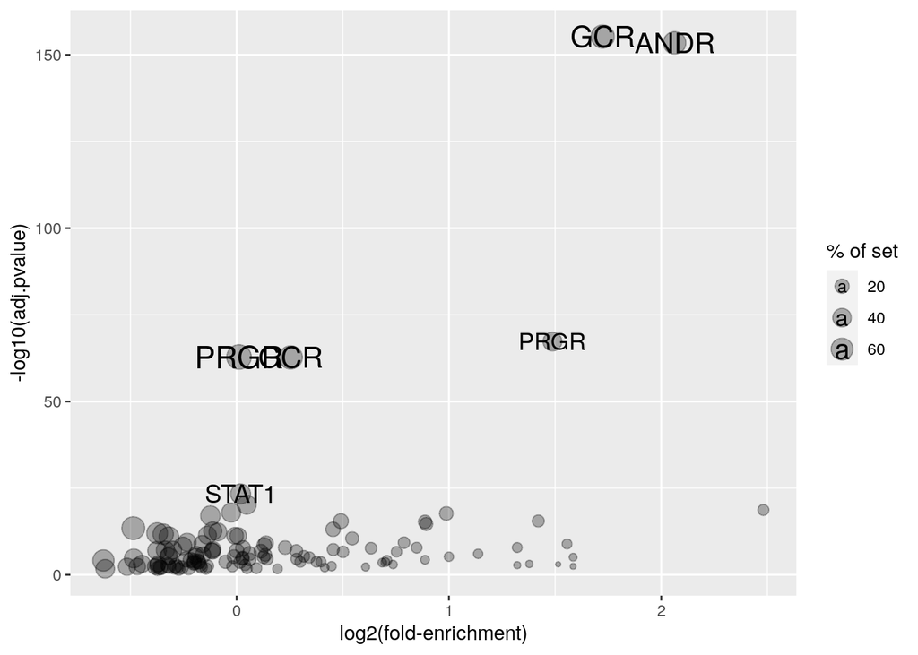

FIGURE 6: Motif enrichment analysis for peaks that are more accessible but not bound by GR or MR upon stress

```r
#plot results
ggplot(ame, aes(log2((1+tp)/(1+fp)), -log10(adj.pvalue), size=tp_percent)) +
  geom_point(alpha=0.3) + geom_text(aes(label=motif_id), data=head(ame)) +
  labs(x="log2(fold-enrichment)", size="% of set")
```

Despite the peaks not being bound by GR or MR, there is still a strong enrichment of GCR and similar motifs in the ATAC peaks (Fig. 6).

We next compare this with the motif enrichment of those peaks that are actually bound by GR.

```r
#obtain genome sequence:
ah <- AnnotationHub(localHub=TRUE)
```

```
## snapshotDate(): 2023-06-23
```

```r
genome <- ah[["AH68356"]]
```

```
## loading from cache
```

```r
seqlevelsStyle(ATACandGR) <- "NCBI"

# we get the sequences corresponding to the peak centers:
peak_seqs <- memes::get_sequence(ATACandGR, genome)
# peak_seqs <- Biostrings::getSeq(genome, peak_centers)
names(peak_seqs) <- as.character(granges(ATACandGR))
peak_seqs
```

```
## DNAStringSet object of length 209:
##       width seq                                             names
##   [1]   415 AGGCCATGGCCAGCATGTGAGG...GCAAAGGGAGAGTTGGACCAAT 1:14244792-14245206
##   [2]   430 GGGAGCGCTGAAGTAACTAGAT...AACACATCCCATTTGAATGTCC 1:20908572-20909001
##   [3]   314 TGGTTTGTGATATTATGCTATG...TCTCCATTCCCTGAATCTTTAT 1:20919786-20920099
##   [4]   558 TTGGCCTCACATTTTCCCGTGA...TTCTGAGAATAAAAACCCCATC 1:39086143-39086700
##   [5]   482 CAGCTAGTGTTGTTCCAAGGAA...GTGTGCTGCCCCTATGTGCTGC 1:39417657-39418138
##   ...   ... ...
## [205]   406 AACCAGGAGGGACACCTGCTTA...TCCCGAGCCTGCCTGCCTGCCT 9:68941045-68941450
## [206]   358 TAGGAGGGCTGAATTTATAAAT...AAAGGCAATGAAGACACAAACT 9:94969115-94969472
## [207]   343 TCCACTGGGCCTTTCTACAAGT...CTGACCAACAGCCTAGCCCTTC X:11898346-11898688
## [208]   392 TGGGGTTCCCAAATTCTGGCCT...GAATGCGCTCATGATTGAACAA X:77409382-77409773
## [209]   449 GGAGGTGTGGCTCCACCTTTCA...GATTAGCTTTGGGACTGGCCTA X:140505795-14050...
```

```r
#query motifs from a single source
motifs <- MotifDb::query(MotifDb, c("Mmusculus", "HOCOMOCOv10"))
#seqlevelsStyle(ATAC_noex) <- "ensembl"

#identify motifs that are enriched in input sequences
ame <- memes::runAme(peak_seqs, database=convert_motifs(motifs), meme_path="/common/meme/bin/")
head(ame)
```

```
## # A tibble: 6 × 17
##    rank motif_db  motif_id motif_alt_id consensus    pvalue adj.pvalue    evalue
##   <int> <chr>     <chr>    <chr>        <chr>         <dbl>      <dbl>     <dbl>
## 1     1 /tmp/Rtm… ANDR     ANDR_MOUSE.… RGDACABN… 1.29e-114  4.80e-112 2.05e-109
## 2     2 /tmp/Rtm… GCR      GCR_MOUSE.H… VRGAACAK… 4.25e-101  2.86e- 98 1.22e- 95
## 3     3 /tmp/Rtm… PRGR     PRGR_MOUSE.… RGAACANY… 1.09e- 63  5.16e- 61 2.20e- 58
## 4     4 /tmp/Rtm… GCR      GCR_MOUSE.H… AGAACAK   8.03e- 48  6.23e- 45 2.65e- 42
## 5     5 /tmp/Rtm… PRGR     PRGR_MOUSE.… AGAACAB   2.14e- 43  1.61e- 40 6.86e- 38
## 6     6 /tmp/Rtm… STAT1    STAT1_MOUSE… BTTTCAST… 4.01e- 18  1.69e- 15 7.21e- 13
## # ℹ 9 more variables: tests <int>, fasta_max <dbl>, pos <int>, neg <int>,
## #   pwm_min <dbl>, tp <int>, tp_percent <dbl>, fp <int>, fp_percent <dbl>
```

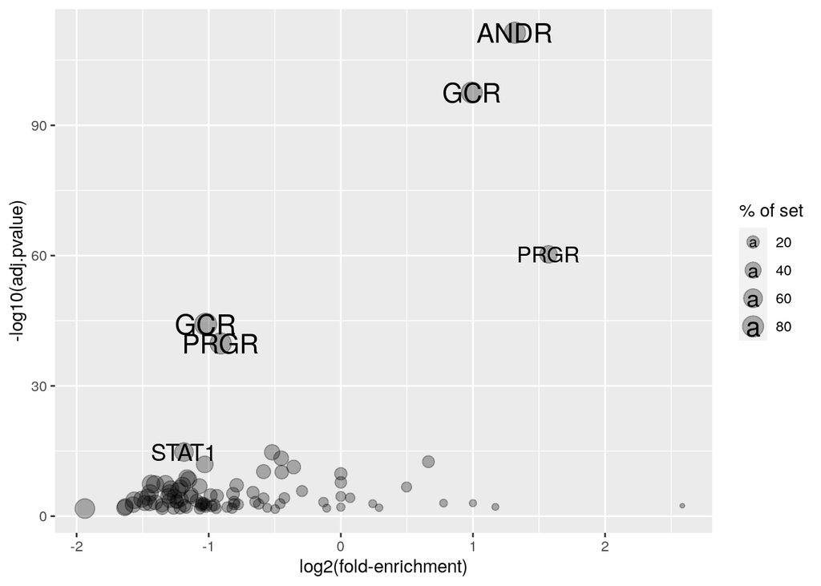

FIGURE 7: Motif enrichment analysis for peaks that are more accessible and bound by GR upon stress

```r
#plot results
ggplot(ame, aes(log2((1+tp)/(1+fp)), -log10(adj.pvalue), size=tp_percent)) +
  geom_point(alpha=0.3) + geom_text(aes(label=motif_id), data=head(ame)) +
  labs(x="log2(fold-enrichment)", size="% of set")
```

Surprisingly, both subsets of peaks show a very similar enrichment of GCR motifs (Fig. 6 & 7), therefore, motif enrichment gives no furthr indication of why some peaks are bound by GR and some aren’t.

## Visualize signal around non-GR/MR peaks

Again, only control and FSS coverage are used to visualize the signal for the regions of accessible peaks without GR/MR signal.

```r
seqlevelsStyle(ATAC_noex) <- "ensembl"

#read signal around non-overlapping peaks
sm2 <- signal2Matrix(tracks, ATAC_noex, w=5, extend=2000)
```

```
## Reading /mnt/bohacek/rebecca/training/EpiC/Project/data_Marrocco/NFtracks//ARS_female_GSM6041847.shifted.bw
```

```
## Reading /mnt/bohacek/rebecca/training/EpiC/Project/data_Marrocco/NFtracks//ARS_female_GSM6041848.shifted.bw
```

```
## Reading /mnt/bohacek/rebecca/training/EpiC/Project/data_Marrocco/NFtracks//ARS_female_GSM6041849.shifted.bw
```

```
## Reading /mnt/bohacek/rebecca/training/EpiC/Project/data_Marrocco/NFtracks//ARS_male_GSM6041850.shifted.bw
```

```
## Reading /mnt/bohacek/rebecca/training/EpiC/Project/data_Marrocco/NFtracks//ARS_male_GSM6041851.shifted.bw
```

```
## Reading /mnt/bohacek/rebecca/training/EpiC/Project/data_Marrocco/NFtracks//ARS_male_GSM6041852.shifted.bw
```

```
## Reading /mnt/bohacek/rebecca/training/EpiC/Project/data_Marrocco/NFtracks//Control_female_GSM6041841.shifted.bw
```

```
## Reading /mnt/bohacek/rebecca/training/EpiC/Project/data_Marrocco/NFtracks//Control_female_GSM6041842.shifted.bw
```

```
## Reading /mnt/bohacek/rebecca/training/EpiC/Project/data_Marrocco/NFtracks//Control_female_GSM6041843.shifted.bw
```

```
## Reading /mnt/bohacek/rebecca/training/EpiC/Project/data_Marrocco/NFtracks//Control_male_GSM6041844.shifted.bw
```

```
## Reading /mnt/bohacek/rebecca/training/EpiC/Project/data_Marrocco/NFtracks//Control_male_GSM6041845.shifted.bw
```

```
## Reading /mnt/bohacek/rebecca/training/EpiC/Project/data_Marrocco/NFtracks//Control_male_GSM6041846.shifted.bw
```

```
## Reading /mnt/bohacek/rebecca/training/EpiC/Project/data_Marrocco/NFtracks//Double-hit_female_GSM6041859.shifted.bw
```

```
## Reading /mnt/bohacek/rebecca/training/EpiC/Project/data_Marrocco/NFtracks//Double-hit_female_GSM6041860.shifted.bw
```

```
## Reading /mnt/bohacek/rebecca/training/EpiC/Project/data_Marrocco/NFtracks//Double-hit_female_GSM6041861.shifted.bw
```

```
## Reading /mnt/bohacek/rebecca/training/EpiC/Project/data_Marrocco/NFtracks//Double-hit_male_GSM6041862.shifted.bw
```

```
## Reading /mnt/bohacek/rebecca/training/EpiC/Project/data_Marrocco/NFtracks//Double-hit_male_GSM6041863.shifted.bw
```

```
## Reading /mnt/bohacek/rebecca/training/EpiC/Project/data_Marrocco/NFtracks//Double-hit_male_GSM6041864.shifted.bw
```

```
## Reading /mnt/bohacek/rebecca/training/EpiC/Project/data_Marrocco/NFtracks//FSS_female_GSM6041853.shifted.bw
```

```
## Reading /mnt/bohacek/rebecca/training/EpiC/Project/data_Marrocco/NFtracks//FSS_female_GSM6041854.shifted.bw
```

```
## Reading /mnt/bohacek/rebecca/training/EpiC/Project/data_Marrocco/NFtracks//FSS_female_GSM6041855.shifted.bw
```

```
## Reading /mnt/bohacek/rebecca/training/EpiC/Project/data_Marrocco/NFtracks//FSS_male_GSM6041856.shifted.bw
```

```
## Reading /mnt/bohacek/rebecca/training/EpiC/Project/data_Marrocco/NFtracks//FSS_male_GSM6041857.shifted.bw
```

```
## Reading /mnt/bohacek/rebecca/training/EpiC/Project/data_Marrocco/NFtracks//FSS_male_GSM6041858.shifted.bw
```

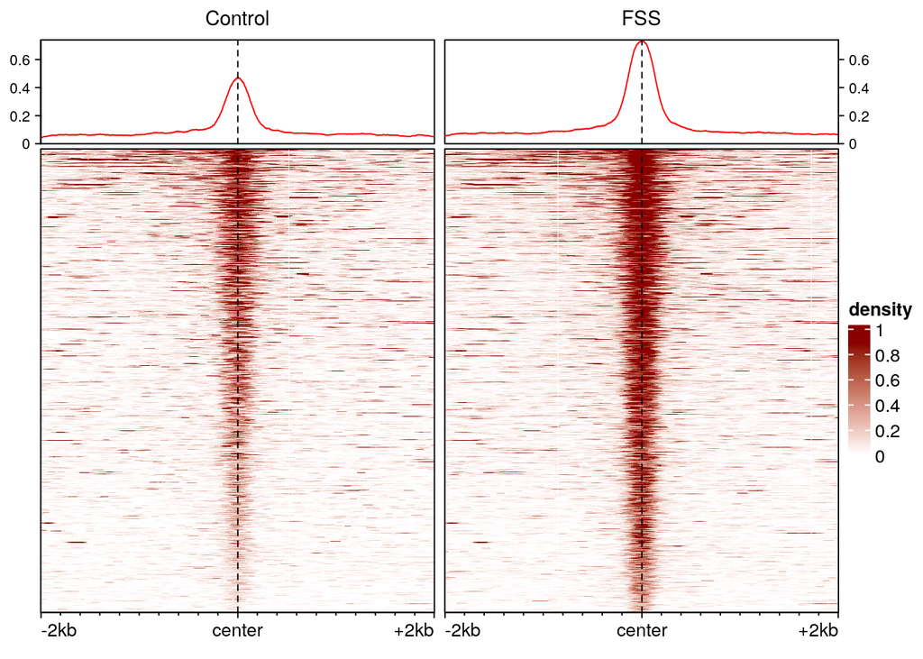

FIGURE 8: Enriched Hatmap showing the read coverage around the sign. more accessible peaks upon stress not bound by GR or MR

```r
#combine all control and all FSS samples
smm2 <- list(Control=mergeSignalMatrices(sm2[grep("Control",names(sm2))]),
            FSS=mergeSignalMatrices(sm2[grep("FSS",names(sm2))]))

#plot signal
plotEnrichedHeatmaps(smm2, trim=0.95, colors = c("white","darkred"))
```

A clear difference is visible between the strength of the coverage signal between control and FSS, showing a higher signal in the FSS group (Fig. 8).

We perform clustering to test, whether different coverage tracks show different patterns.

```r
#look whether there are any clusters emerging between those peaks
#check for number of clusters that define a certain variability
#cl <- clusterSignalMatrices(smm2, k=2:10)
#ggplot(cl$varExplained, aes(k, varExplained)) + geom_line()
```

```r
#cluster signal
#set seed to ensure reproducibility of clustering
set.seed(123)
#clustering signal with kmeans into 4 clusters, the relative signal instead of absolute values is used
cl <- epiwraps::clusterSignalMatrices(smm2, k=4, scaleRows = TRUE, seed=TRUE) #4 clusters explain 75% of variance
```

```
##   ~75% of the variance explained by clusters
```

```r
#use scaleRows=RUE?

#add cluster information to the GRanges object
ATAC_noex$clusters <- cl
#regions
#compare number of regions in each cluster
table(cl)
```

```
## cl
##   1   2   3   4
## 436  97   8 110
```

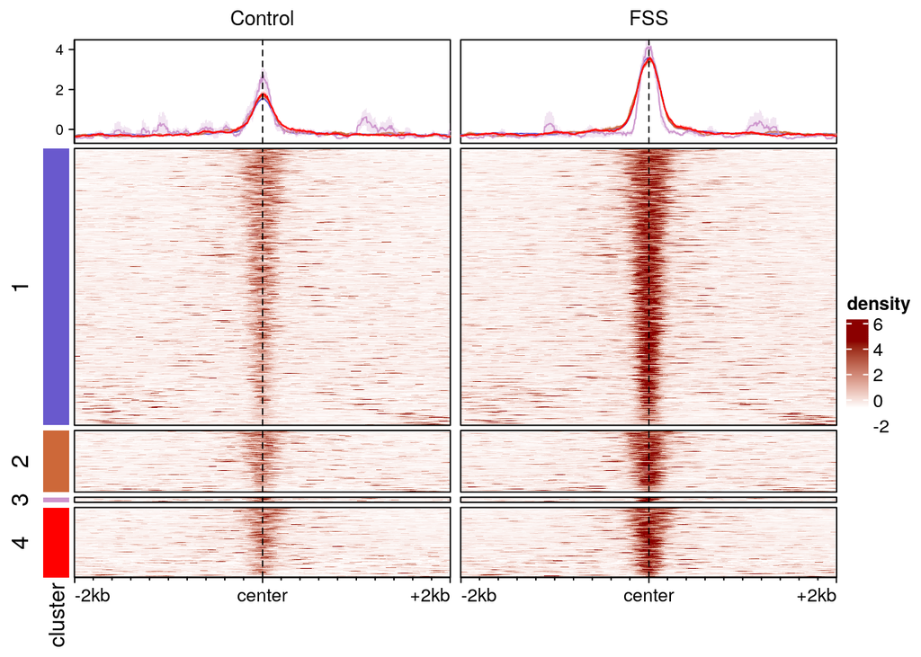

FIGURE 9: Enriched Hatmap showing the read coverage around the sign. more accessible peaks upon stress not bound by GR or MR for the individual clusters

```r
#define colors for clusters
mycolors <-c("1"="slateblue3", "2"="sienna3", "3"="plum3", "4"="red", "5"="blue")
#plot heatmap with clusters
plotEnrichedHeatmaps(smm2, row_split=cl, mean_color = mycolors, colors=c("white", "darkred"), scale_row="global")
```

By plotting the tracks split into clusters, no clear differences between the signals emerge, therefore, the clusters are plotted individually for the two groups (Fig. 9).

```r
#overlay for one cluster all of the marks
d<-meltSignals(smm2, splitBy=cl)
head(d)
```

```
##   split position  sample       mean         SD          SE     median
## 1     1    -2000 Control 0.04204394 0.07594910 0.003637302 0.01374930
## 2     1    -1995 Control 0.04272210 0.08100643 0.003879504 0.01374930
## 3     1    -1990 Control 0.04282819 0.08054065 0.003857198 0.01374930
## 4     1    -1985 Control 0.04328236 0.08003593 0.003833026 0.01536389
## 5     1    -1980 Control 0.04500565 0.08237187 0.003944897 0.01536389
## 6     1    -1975 Control 0.04736778 0.09542530 0.004570043 0.01536389
```

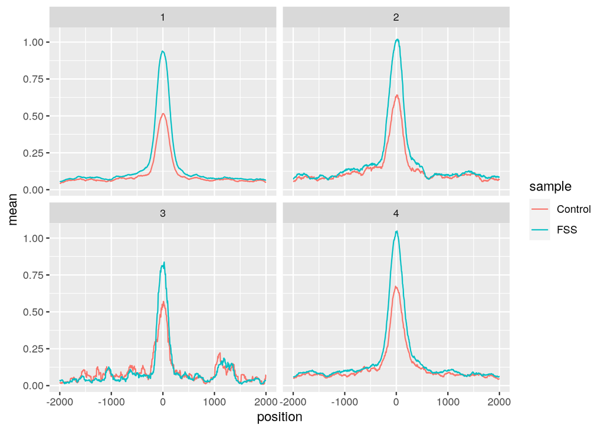

FIGURE 10: Read coverage between control and FSS samples for each cluster

```r
ggplot(d, aes(position, mean, colour=sample))+geom_line() +facet_wrap(~split)
```

Looking at the individual clusters, the pattern seems very similar in all of them, with the peak center showing an enhanced signal in the center in the FSS group compared to the control group (Fig. 10). No clear differences in the signal between the different clusters emerge.

# Motif scanning

Next, we test whether the motif occurence (GCR) differs between those peaks with and without a GR signal. For this, motif scanning will be performed using the GCR motif (Fig. 11). A peak_center of 140 bp will be used

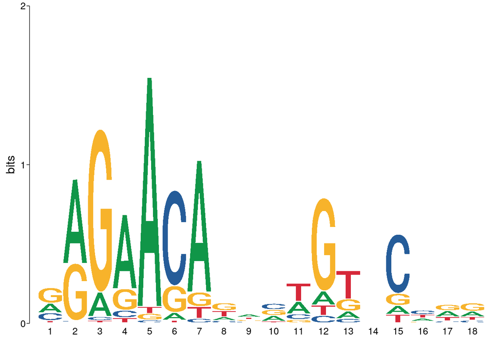

FIGURE 11: GCR motif

```r
#obtain GR motif
motif <- MotifDb::query(MotifDb, c("GCR","Mus"))[[1]]
#plot motif
view_motifs(motif)
```

```r
#convert motif format
motif2 <- convert_motifs(motif, class="TFBSTools-PFMatrix")
genome <- Rsamtools::FaFile("/reference/Mus_musculus/Ensembl/GRCm38/Sequence/WholeGenomeFasta/Mus_musculus.GRCm38.dna_sm.primary_assembly.fa")
```

## check ATAC peaks with overlap

```r
#extract center of peaks
peak_centers <- resize(ATACandGR, fix="center", width=140)

#scan set of sequences for motif occurence
moi <- motifmatchr::matchMotifs(motif2, subject = peak_centers, out="positions", p.cutoff=1e-5, genome=genome)[[1]]
head(moi)
```

```
## GRanges object with 6 ranges and 1 metadata column:
##       seqnames              ranges strand |     score
##          <Rle>           <IRanges>  <Rle> | <numeric>
##   [1]        1   20919970-20919987      + |   14.9214
##   [2]        1   20919969-20919986      - |   16.5376
##   [3]        1   74007891-74007908      + |   15.1434
##   [4]        1   74014802-74014819      + |   13.1231
##   [5]        1   74014801-74014818      - |   16.6359
##   [6]        1 119048125-119048142      - |   13.7242
##   -------
##   seqinfo: 49 sequences from an unspecified genome; no seqlengths
```

```r
#read signal around non-overlapping peaks
sm2 <- signal2Matrix(tracks, moi, w=5, extend=500)
```

```
## Reading /mnt/bohacek/rebecca/training/EpiC/Project/data_Marrocco/NFtracks//ARS_female_GSM6041847.shifted.bw
```

```
## Reading /mnt/bohacek/rebecca/training/EpiC/Project/data_Marrocco/NFtracks//ARS_female_GSM6041848.shifted.bw
```

```
## Reading /mnt/bohacek/rebecca/training/EpiC/Project/data_Marrocco/NFtracks//ARS_female_GSM6041849.shifted.bw
```

```
## Reading /mnt/bohacek/rebecca/training/EpiC/Project/data_Marrocco/NFtracks//ARS_male_GSM6041850.shifted.bw
```

```
## Reading /mnt/bohacek/rebecca/training/EpiC/Project/data_Marrocco/NFtracks//ARS_male_GSM6041851.shifted.bw
```

```
## Reading /mnt/bohacek/rebecca/training/EpiC/Project/data_Marrocco/NFtracks//ARS_male_GSM6041852.shifted.bw
```

```
## Reading /mnt/bohacek/rebecca/training/EpiC/Project/data_Marrocco/NFtracks//Control_female_GSM6041841.shifted.bw
```

```
## Reading /mnt/bohacek/rebecca/training/EpiC/Project/data_Marrocco/NFtracks//Control_female_GSM6041842.shifted.bw
```

```
## Reading /mnt/bohacek/rebecca/training/EpiC/Project/data_Marrocco/NFtracks//Control_female_GSM6041843.shifted.bw
```

```
## Reading /mnt/bohacek/rebecca/training/EpiC/Project/data_Marrocco/NFtracks//Control_male_GSM6041844.shifted.bw
```

```
## Reading /mnt/bohacek/rebecca/training/EpiC/Project/data_Marrocco/NFtracks//Control_male_GSM6041845.shifted.bw
```

```
## Reading /mnt/bohacek/rebecca/training/EpiC/Project/data_Marrocco/NFtracks//Control_male_GSM6041846.shifted.bw
```

```
## Reading /mnt/bohacek/rebecca/training/EpiC/Project/data_Marrocco/NFtracks//Double-hit_female_GSM6041859.shifted.bw
```

```
## Reading /mnt/bohacek/rebecca/training/EpiC/Project/data_Marrocco/NFtracks//Double-hit_female_GSM6041860.shifted.bw
```

```
## Reading /mnt/bohacek/rebecca/training/EpiC/Project/data_Marrocco/NFtracks//Double-hit_female_GSM6041861.shifted.bw
```

```
## Reading /mnt/bohacek/rebecca/training/EpiC/Project/data_Marrocco/NFtracks//Double-hit_male_GSM6041862.shifted.bw
```

```
## Reading /mnt/bohacek/rebecca/training/EpiC/Project/data_Marrocco/NFtracks//Double-hit_male_GSM6041863.shifted.bw
```

```
## Reading /mnt/bohacek/rebecca/training/EpiC/Project/data_Marrocco/NFtracks//Double-hit_male_GSM6041864.shifted.bw
```

```
## Reading /mnt/bohacek/rebecca/training/EpiC/Project/data_Marrocco/NFtracks//FSS_female_GSM6041853.shifted.bw
```

```
## Reading /mnt/bohacek/rebecca/training/EpiC/Project/data_Marrocco/NFtracks//FSS_female_GSM6041854.shifted.bw
```

```
## Reading /mnt/bohacek/rebecca/training/EpiC/Project/data_Marrocco/NFtracks//FSS_female_GSM6041855.shifted.bw
```

```
## Reading /mnt/bohacek/rebecca/training/EpiC/Project/data_Marrocco/NFtracks//FSS_male_GSM6041856.shifted.bw
```

```
## Reading /mnt/bohacek/rebecca/training/EpiC/Project/data_Marrocco/NFtracks//FSS_male_GSM6041857.shifted.bw
```

```
## Reading /mnt/bohacek/rebecca/training/EpiC/Project/data_Marrocco/NFtracks//FSS_male_GSM6041858.shifted.bw
```

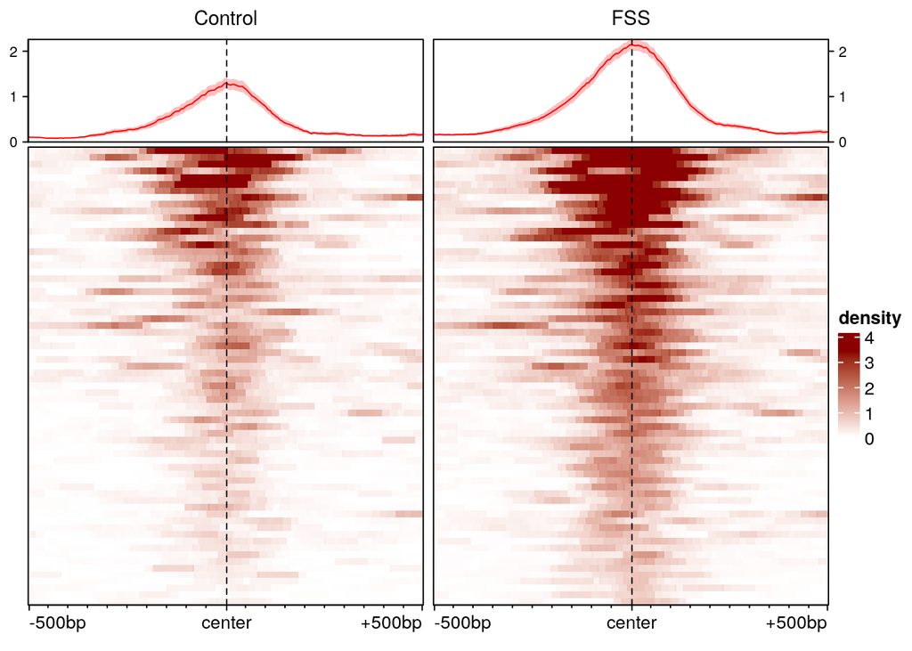

FIGURE 12: Enriched Hatmap showing the read coverage around the GCR motif occurrences

```r
smm2 <- list(Control=mergeSignalMatrices(sm2[grep("Control",names(sm2))]),
            FSS=mergeSignalMatrices(sm2[grep("FSS",names(sm2))]))
plotEnrichedHeatmaps(smm2, trim=0.95, colors = c("white","darkred"))
```

```r
#calculate motif occurence
peaks_w_motif <- ATACandGR[overlapsAny(ATACandGR,moi)]
length(peaks_w_motif) #55
```

```
## [1] 55
```

```r
length(ATACandGR) #209
```

```
## [1] 209
```

```r
length(peaks_w_motif)/length(ATACandGR) #0.2631579
```

```
## [1] 0.2631579
```

The FSS group shows higher signal for the motif occurrences (Fig. 12). 26% of the accessible ATAC peaks that are bound by GR contain the specified GCR motif.

CLustering is performed using 3 clusters.

```r
#cluster signal
#set seed to ensure reproducibility of clustering
set.seed(123)
#clustering signal with kmeans into 3 clusters, the relative signal instead of absolute values is used
cl <- epiwraps::clusterSignalMatrices(smm2, k=3, scaleRows = TRUE, seed=TRUE)
```

```
##   ~55% of the variance explained by clusters
```

```r
#add cluster information to the GRanges object
moi$clusters <- cl
#regions
#compare number of regions in each cluster
table(cl)
```

```
## cl
##  1  2  3
## 10 22 36
```

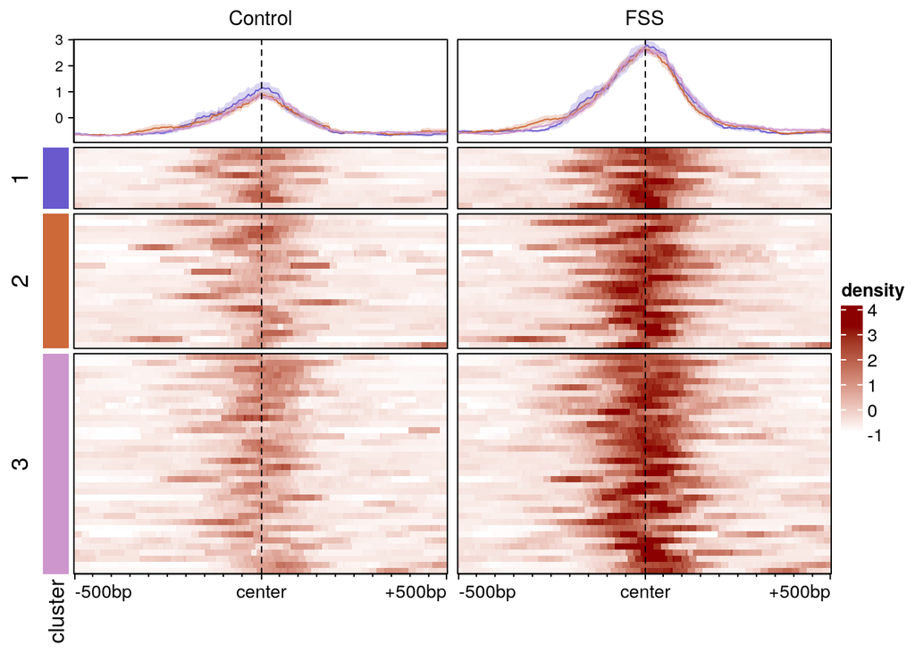

FIGURE 13: Enriched Hatmap showing the read coverage around the motif occurrences for all clusters

```r
#define colors for clusters
mycolors <-c("1"="slateblue3", "2"="sienna3", "3"="plum3", "4"="red", "5"="blue")
#plot heatmap with clusters
plotEnrichedHeatmaps(smm2, row_split=cl, mean_color = mycolors, colors=c("white", "darkred"), scale_row="global")
```

The motif occurrence seems to be similar over all clusters, showing enhanced signal in the center in the FSS group (Fig. 13).

## check ATAC peaks without overlap

```r
#extract center of peaks
peak_centers <- resize(ATAC_noex, fix="center", width=140)

#find motif occurences
seqlevelsStyle(ATAC_noex) <- "ensembl"

#scan set of sequences for motif occurence
moi <- motifmatchr::matchMotifs(motif2, subject = peak_centers, out="positions", p.cutoff=1e-5, genome=genome)[[1]]
head(moi)
```

```
## GRanges object with 6 ranges and 1 metadata column:
##       seqnames            ranges strand |     score
##          <Rle>         <IRanges>  <Rle> | <numeric>
##   [1]        1   9851601-9851618      - |   14.3282
##   [2]        1 15913771-15913788      + |   12.9604
##   [3]        1 52957031-52957048      + |   13.8419
##   [4]        1 61540120-61540137      + |   14.9381
##   [5]        1 72673240-72673257      - |   16.7293
##   [6]        1 90917713-90917730      + |   12.9746
##   -------
##   seqinfo: 49 sequences from an unspecified genome; no seqlengths
```

```r
#read signal around non-overlapping peaks
sm2 <- signal2Matrix(tracks, moi, w=5, extend=500)
```

```
## Reading /mnt/bohacek/rebecca/training/EpiC/Project/data_Marrocco/NFtracks//ARS_female_GSM6041847.shifted.bw
```

```
## Reading /mnt/bohacek/rebecca/training/EpiC/Project/data_Marrocco/NFtracks//ARS_female_GSM6041848.shifted.bw
```

```
## Reading /mnt/bohacek/rebecca/training/EpiC/Project/data_Marrocco/NFtracks//ARS_female_GSM6041849.shifted.bw
```

```
## Reading /mnt/bohacek/rebecca/training/EpiC/Project/data_Marrocco/NFtracks//ARS_male_GSM6041850.shifted.bw
```

```
## Reading /mnt/bohacek/rebecca/training/EpiC/Project/data_Marrocco/NFtracks//ARS_male_GSM6041851.shifted.bw
```

```
## Reading /mnt/bohacek/rebecca/training/EpiC/Project/data_Marrocco/NFtracks//ARS_male_GSM6041852.shifted.bw
```

```
## Reading /mnt/bohacek/rebecca/training/EpiC/Project/data_Marrocco/NFtracks//Control_female_GSM6041841.shifted.bw
```

```
## Reading /mnt/bohacek/rebecca/training/EpiC/Project/data_Marrocco/NFtracks//Control_female_GSM6041842.shifted.bw
```

```
## Reading /mnt/bohacek/rebecca/training/EpiC/Project/data_Marrocco/NFtracks//Control_female_GSM6041843.shifted.bw
```

```
## Reading /mnt/bohacek/rebecca/training/EpiC/Project/data_Marrocco/NFtracks//Control_male_GSM6041844.shifted.bw
```

```
## Reading /mnt/bohacek/rebecca/training/EpiC/Project/data_Marrocco/NFtracks//Control_male_GSM6041845.shifted.bw
```

```
## Reading /mnt/bohacek/rebecca/training/EpiC/Project/data_Marrocco/NFtracks//Control_male_GSM6041846.shifted.bw
```

```
## Reading /mnt/bohacek/rebecca/training/EpiC/Project/data_Marrocco/NFtracks//Double-hit_female_GSM6041859.shifted.bw
```

```
## Reading /mnt/bohacek/rebecca/training/EpiC/Project/data_Marrocco/NFtracks//Double-hit_female_GSM6041860.shifted.bw
```

```
## Reading /mnt/bohacek/rebecca/training/EpiC/Project/data_Marrocco/NFtracks//Double-hit_female_GSM6041861.shifted.bw
```

```
## Reading /mnt/bohacek/rebecca/training/EpiC/Project/data_Marrocco/NFtracks//Double-hit_male_GSM6041862.shifted.bw
```

```
## Reading /mnt/bohacek/rebecca/training/EpiC/Project/data_Marrocco/NFtracks//Double-hit_male_GSM6041863.shifted.bw
```

```
## Reading /mnt/bohacek/rebecca/training/EpiC/Project/data_Marrocco/NFtracks//Double-hit_male_GSM6041864.shifted.bw
```

```
## Reading /mnt/bohacek/rebecca/training/EpiC/Project/data_Marrocco/NFtracks//FSS_female_GSM6041853.shifted.bw
```

```
## Reading /mnt/bohacek/rebecca/training/EpiC/Project/data_Marrocco/NFtracks//FSS_female_GSM6041854.shifted.bw
```

```
## Reading /mnt/bohacek/rebecca/training/EpiC/Project/data_Marrocco/NFtracks//FSS_female_GSM6041855.shifted.bw
```

```
## Reading /mnt/bohacek/rebecca/training/EpiC/Project/data_Marrocco/NFtracks//FSS_male_GSM6041856.shifted.bw
```

```
## Reading /mnt/bohacek/rebecca/training/EpiC/Project/data_Marrocco/NFtracks//FSS_male_GSM6041857.shifted.bw
```

```
## Reading /mnt/bohacek/rebecca/training/EpiC/Project/data_Marrocco/NFtracks//FSS_male_GSM6041858.shifted.bw
```

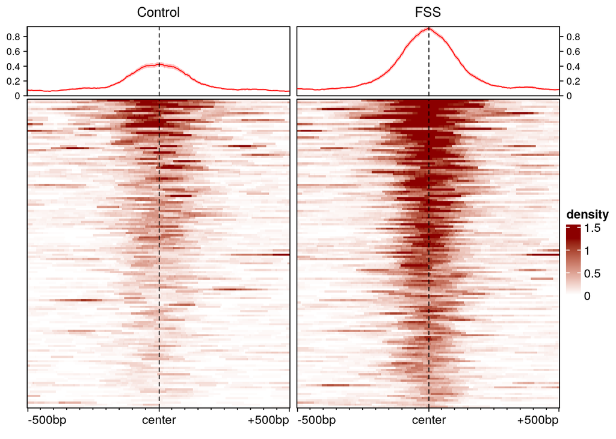

FIGURE 14: Enriched Hatmap showing the read coverage around the GCR motif occurrences

```r
smm2 <- list(Control=mergeSignalMatrices(sm2[grep("Control",names(sm2))]),
            FSS=mergeSignalMatrices(sm2[grep("FSS",names(sm2))]))
plotEnrichedHeatmaps(smm2, trim=0.95, colors = c("white","darkred"))
```

```r
#calculate motif occurence
peaks_w_motif <- ATAC_noex[overlapsAny(ATAC_noex,moi)]
length(peaks_w_motif) #124
```

```
## [1] 124
```

```r
length(ATAC_noex) #651
```

```
## [1] 651
```

```r
length(peaks_w_motif)/length(ATAC_noex) #0.1904762
```

```
## [1] 0.1904762
```

The FSS group shows higher signal for the motif occurrences (Fig. 14). However, from the accessible ATAC peaks that are not bound by GR or MR, only 19% contain the specified GCR motif.

CLustering is performed using 4 clusters.

```r
#cluster signal
#set seed to ensure reproducibility of clustering
set.seed(123)
#clustering signal with kmeans into 4 clusters, the relative signal instead of absolute values is used
cl <- epiwraps::clusterSignalMatrices(smm2, k=4, scaleRows = TRUE, seed=TRUE) #4 clusters explain 71% of variance
```

```
##   ~71% of the variance explained by clusters
```

```r
#add cluster information to the GRanges object
moi$clusters <- cl
#regions
#compare number of regions in each cluster
table(cl)
```

```
## cl
##  1  2  3  4
##  2 86 38 16
```

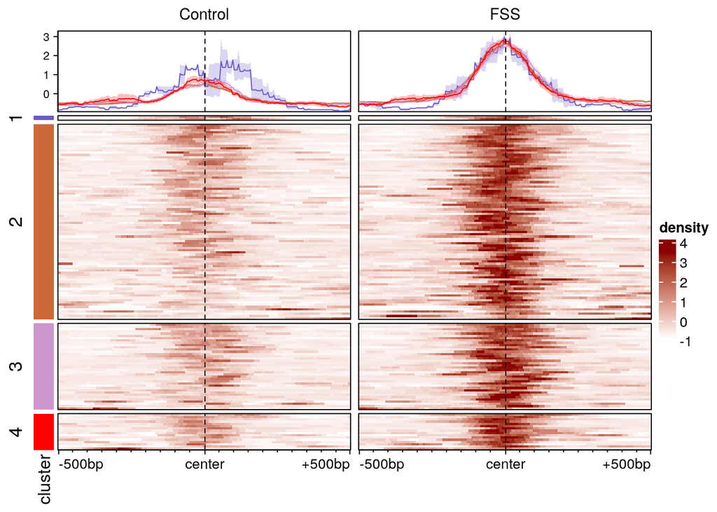

FIGURE 15: Enriched Hatmap showing the read coverage around the motif occurrences for all clusters

```r
#define colors for clusters
mycolors <-c("1"="slateblue3", "2"="sienna3", "3"="plum3", "4"="red", "5"="blue")
#plot heatmap with clusters
plotEnrichedHeatmaps(smm2, row_split=cl, mean_color = mycolors, colors=c("white", "darkred"), scale_row="global")
```

The motif occurrence seems to be similar over all clusters, showing enhanced signal in the center in the FSS group (Fig. 15). Smaller clusters (cluster 1) show a less smooth signal, which could be evaluated further.